# Lab 9 – One-Way ANOVA

```r
library(tidyverse)
library(infer)
library(ggridges)
library(broom)
```

## Today’s Data

These data come from the Gapminder Foundation, an organization interested in increasing the use and understanding of statistics and other information about social, economic and environmental development at local, national and global levels.

Today we will be comparing math achievement scores across continents and years. Math achievement was measured for 42 countries based on their average score for the grade 8 international TIMSS test.

```r
math_scores <- read_csv(here::here("Week 9 - ANOVA",
                                   "Lab",
                                   "data",
                                   "math_scores.csv")
                        )


# Creating a year_cat variable that is the categorical version of year
math_scores <- mutate(math_scores,
                      year_cat = as.factor(year)
                      )

# Removing the missing values from the grade_8_math_score variable
math_scores <- drop_na(data = math_scores,
                       grade_8_math_score)
```

## Data Visualizations

The first step for a statistical analysis should always be creating visualizations of the data. Similar to what you are expected to do for your project, you will make three density ridge plots:

- visualizing the relationship between math score and year
- visualizing the relationship between math score and continent
- visualizing the relationship between math score with both year **and** continent

**Question 1** – Fill in the code below to visualize the distribution of grade 8 math scores over time.

**Don’t forget to include axis labels!**

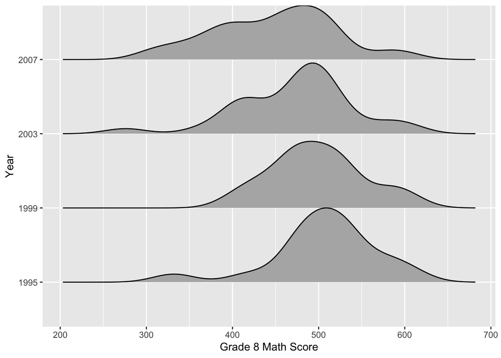

```r
ggplot(data = math_scores,
       mapping = aes(x = grade_8_math_score,
                     y = year_cat)) +
  geom_density_ridges(scale = 1) +
  labs(x = "Grade 8 Math Score",
       y = "Year")
```

*Note:* I’ve included a `scale = 1` argument to show you how you can get the density plots not to overlap!

**Question 2** – What do you see in the plot you made? How do the centers (means) of the distributions compare? What about the variability (spread) of the distributions?

**Question 3** – Write the code to visualize the distribution of grade 8 math scores for the six different continents.

**Don’t forget to include axis labels!**

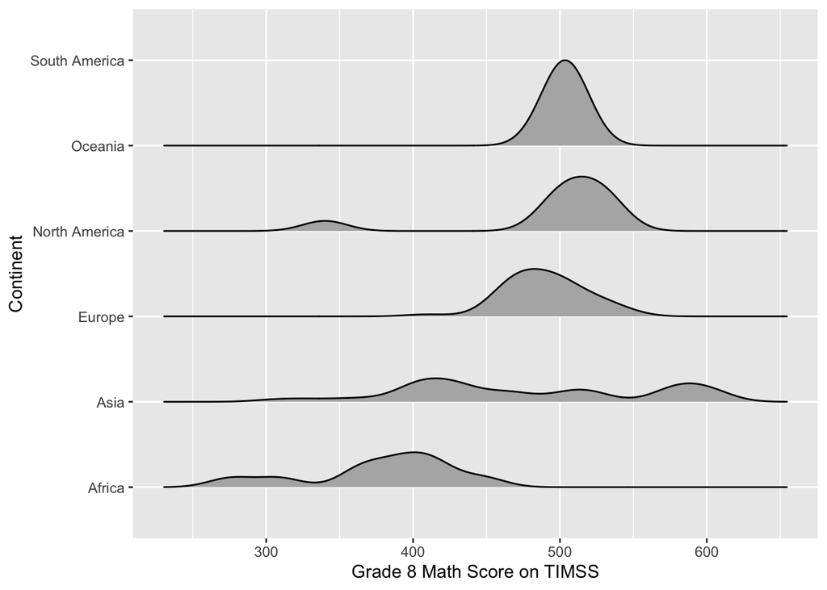

```r
ggplot(data = math_scores,
       mapping = aes(x = grade_8_math_score,
                     y = continent)) +
  geom_density_ridges(scale = 1) +
  labs(x = "Grade 8 Math Score on TIMSS",
       y = "Continent")
```

**Question 4** – What do you see in the plot you made? How do the centers (means) of the distributions compare? What about the variability (spread) of the distributions?

**Question 5** – Write the code to visualize the distribution of grade 8 math scores for the six different continents for each of the four years.

**Remember, you could either include a facet or a color here!** **Also remember you can use `alpha` to change the transparency of your density ridges!**

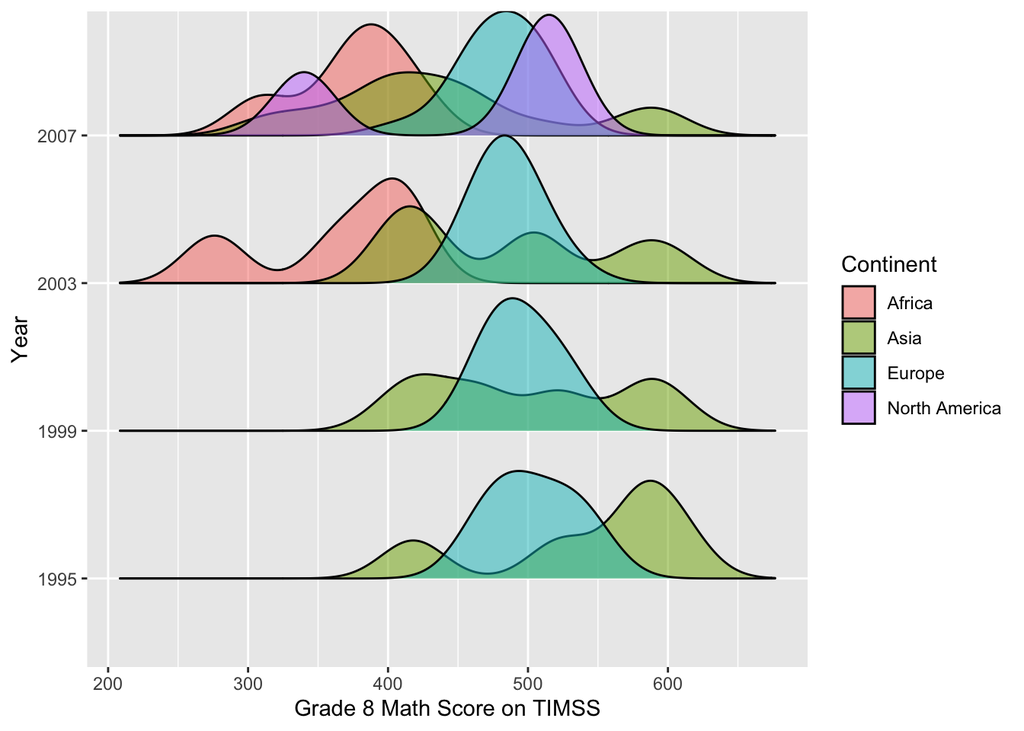

```r
ggplot(data = math_scores,
       mapping = aes(x = grade_8_math_score,
                     y = year_cat,
                     fill = continent)) +
  geom_density_ridges(alpha = 0.5, scale = 1) +
  labs(x = "Grade 8 Math Score on TIMSS",
       y = "Year",
       fill = "Continent")
```

**Question 6** – What do you see in the plot you made? Does it seem that the relationship between year and grade 8 math scores changes based on the continent of the student?

It looks like across the years Europe’s scores stay about the same. For the years we have data, it also appears that Africa’s scores stay about the same. Asia’s scores, however, seem to change throughout the years, migrating to lower scores over time.

## Statistical Model

### Model Conditions

An ANOVA has model conditions that are very similar to what we learned for linear regression. In this section we will evaluate the conditions of the model.

For this section, it might be helpful to know how many observations there are for each year and for each continent. I have written code below to provide you with a table of these numbers:

```r
count(math_scores, continent, year) %>%
  pivot_wider(names_from = continent,
              values_from = n,
              values_fill = 0) %>%
  janitor::adorn_totals(where = c("row", "col"))
```

```
  year Africa Asia Europe North America Oceania South America Total
  1999      1   10      8             2       0             0    21
  2003      4   11     12             2       1             0    30
  2007      5   18     16             3       1             1    44
  1995      0    5     10             2       1             1    19
 Total     10   44     46             9       3             2   114
```

#### Independence

Based on the table we know:

- each year has measurements on about six continents
- each continent has measurements for about four years

Use this information to evaluate the condition of independence of observations.

**Question 7** – Is it reasonable to assume that the observations *within* a continent are independent of each other?

No, these observations are related in time.

**Question 8** – Is it reasonable to assume that the observations *within* a year are independent of each other?

Yes, I don’t see major relationships between continents. Each country can only belong to one continent. Additionally, there are very few countries who border two different continents (e.g., Russia).

**Question 9** – Is it reasonable to assume that the observations *between* continents are independent of each other?

Again, yes, I don’t see any major relationships between continents. Each country can only belong to one continent. Additionally, there are very few countries who border two different continents (e.g., Russia).

**Question 10** – Is it reasonable to assume that the observations *between* a years are independent of each other?

No, these observations are related in time.

#### Normality

Now we will evaluate the normality of the the distributions of grade 8 math scores across years and across continents – the plot you created in #5. *Keep in mind, the normality condition is very important when the sample sizes for each group are relatively small.*

**Question 11** – Is it reasonable to say that the grade 8 math scores across the four years and six continents are normally distributed?

Not really, many of the distributions have multiple modes (e.g., Africa and Asia in 2003).

#### Equal Variance

Now we will evaluate the normality of the the distributions of grade 8 math scores across years and across continents – the plot you created in #5. *Keep in mind, the constant variance condition is especially important when the sample sizes differ between groups.*

For this section, it might be helpful to know the standard deviations for each year / continent combo. I have written code below to provide you with a table of these numbers:

*Keep in mind a standard deviation of `NA` can happen for two reasons, (1) there is no data, or (2) there is only one observation.*

```r
math_scores %>%
  group_by(year, continent) %>%
  summarize(var = var(grade_8_math_score, na.rm = TRUE)
            ) %>%
  pivot_wider(names_from = continent, values_from = var)
```

```
# A tibble: 4 × 7
# Groups:   year [4]
   year  Asia Europe `North America` Oceania `South America` Africa
  <dbl> <dbl>  <dbl>           <dbl>   <dbl>           <dbl>  <dbl>
1  1995 5807.   834.            512       NA              NA    NA
2  1999 5398.   508.            612.      NA              NA    NA
3  2003 5801.   381.            338       NA              NA  3876.
4  2007 7091.   754.          10257.      NA              NA  1725.
```

But, we have learned tools for remedying this issue! Let’s take the log of `grade_8_math_score` and see how the variances compare.

```r
math_scores %>%
  group_by(year, continent) %>%
  summarize(log_var = var(log(grade_8_math_score))
            ) %>%
  pivot_wider(names_from = continent, values_from = log_var)
```

```
# A tibble: 4 × 7
# Groups:   year [4]
   year   Asia  Europe `North America` Oceania `South America`  Africa
  <dbl>  <dbl>   <dbl>           <dbl>   <dbl>           <dbl>   <dbl>
1  1995 0.0229 0.00327         0.00199      NA              NA NA
2  1999 0.0217 0.00203         0.00227      NA              NA NA
3  2003 0.0239 0.00158         0.00127      NA              NA  0.0341
4  2007 0.0355 0.00346         0.0576       NA              NA  0.0134
```

**Question 12** – Based on the variances in the table above, is it reasonable to say that the *log* grade 8 math scores across the four years and six continents have equal variability?

## One-Way ANOVA Inference

We are going to test out both methods for conducting a hypothesis test for an ANOVA – theory-based and simulation-based methods. Keep in mind **both** methods require independence of observations **and** equal variability. Normality, however, is only a condition of theory-based methods.

### Testing for a Difference Between Years

Since the distribution of grade 8 math scores across the four years wasn’t horribly not Normal, let’s give a theory-based method a try.

**Question 13** – Fill in the code below to conduct a one-way ANOVA

*Keep in mind the response variable comes first and the explanatory variable comes second!*

```r
aov(grade_8_math_score ~ year, data = math_scores) %>%
  broom::tidy()
```

```
# A tibble: 2 × 6
  term         df   sumsq meansq statistic   p.value
  <chr>     <dbl>   <dbl>  <dbl>     <dbl>     <dbl>
1 year          1  58924. 58924.      14.1  0.000276
2 Residuals   112 467981.  4178.      NA   NA
```

**Question 14** – At an $\alpha = 0.1$, what decision would you reach for your hypothesis test?

Reject $H_0$ the p-value of 0000276 is much lower than 0.1.

**Question 15** – What would you conclude about the relationship between the mean grade 8 math scores and year?

### Testing for a Difference Between Continents

Since the distribution of grade 8 math scores across the six continents didn’t look very Normal, so let’s give a simulation-based method a try.

I’ve gotten you started by calculating the observed F-statistic for the relationship between a country’s grade 8 math score and its continent.

```r
obs_F <- math_scores %>%
  specify(response = grade_8_math_score,
          explanatory = continent) %>%
  calculate(stat = "F")
```

**Question 16** – Write the code to generate a permutation distribution of resampled F-statistics.

```r
null_dist <- math_scores %>%
  specify(response = grade_8_math_score,
          explanatory = continent) %>%
  hypothesise(null = "independence") %>%
  generate(reps = 1000, type = "permute") %>%
  calculate(stat = "F")
```

**Question 17** – Visualize the null distribution and shade how the p-value should be calculated

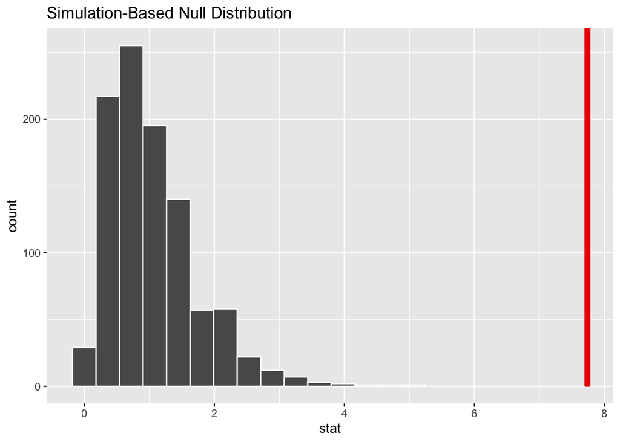

```r
visualize(null_dist) +
  shade_p_value(obs_stat = obs_F,
                direction = "greater")
```

**Question 18** – Calculate the p-value for the observed F-statistic

```r
get_p_value(null_dist,
            obs_stat = obs_F,
            direction = "greater")
```

```
# A tibble: 1 × 1
  p_value
    <dbl>
1       0
```

**Question 19** – At an $\alpha = 0.1$, what decision would you reach for your hypothesis test?

Reject $H_0$, the p-value of approximately 0 is much lower than 0.1.

**Question 20** – What would you conclude about the relationship between the mean grade 8 math scores and continent?

There is evidence that at least one continent has a different mean grade 8 math score.